# Entrega 2 - Grupo 12

*Introducción a la Minería de Datos*

Pedro Belmonte, Jorge Fabry, Víctor Garrido, Pablo Ilabaca

# Introducción

Para esta entrega, ahondamos en el trabajo realizado anteriormente. En la primera parte hacemos todo un manejo de datos para convertir el dataset en tablas utilizables por los clasificadores. Luego, se utilizan distintos clasificadores y técnicas de balanceo de clases para buscar un modelo que permita predecir si un juego será o no una decepción.

# 1 - Importación de Data Set

El dataset original es extraido de https://www.kaggle.com/silver1996/videogames/data. En una primera instancia, se utilizó el siguiente Script de R para filtrar el dataset.

```
########### 1 - creacion de la tabla y tipos ################
## cambiar esta linea al path del .csv
videogames <- read_csv("R/entrega 2/Video_Games_Sales_as_at_22_Dec_2016.csv")

# se eliminan las filas que tengan NA (quedan aprox 7000 resultados)
filtered_vid = na.omit(videogames)

# se arreglan los tipos: user-score a numeric, los otros char a factor
filtered_vid$User_Score <- as.numeric(filtered_vid$User_Score)
character_vars <- lapply(filtered_vid, class) == "character"
filtered_vid[, character_vars] <- lapply(filtered_vid[, character_vars], as.factor)

# se define la diferencia necesaria para considerar que un juego fue un fiasco
# (al comparar user_score con critic_score)
dif_for_fail = 2

#se crea y pobla la columna que define si un juego es un fiasco o no
filtered_vid["Is_Fiasco"] <- NA
filtered_vid$Is_Fiasco <- ((filtered_vid$Critic_Score / 10) - filtered_vid$User_Score) > dif_for_fail

########## 2 - reduccion de dimensionalidad para Machine Learning ##########
## eliminar categorias
reduced <- filtered_vid
reduced["User_Count"] <- NULL
reduced["User_Score"] <- NULL
reduced["Critic_Count"] <- NULL
reduced["Other_Sales"] <- NULL
reduced["EU_Sales"] <- NULL
reduced["JP_Sales"] <- NULL
reduced["NA_Sales"] <- NULL
reduced["Year_of_Release"] <- NULL
reduced["Name"] <- NULL
reduced["Developer"] <- NULL
reduced["Developer"] <- NULL
## tomar solo las n consolas mas populares:
n = 5
popular_console <- reduced
popular_console["counter"] <- 1
popular_console = aggregate(counter ~ Platform,popular_console,FUN=sum)
popular_console = popular_console[order(popular_console$counter,decreasing = T),]
reduced <- reduced[reduced$Platform %in% popular_console[1:n,]$Platform,]

## tomar solo los n mayores publicadores:
n = 10
popular_publisher <- reduced
popular_publisher["counter"] <- 1
popular_publisher = aggregate(counter ~ Publisher,popular_publisher,FUN=sum)
popular_publisher = popular_publisher[order(popular_publisher$counter,decreasing = T),]
reduced <- reduced[reduced$Publisher %in% popular_publisher[1:n,]$Publisher,]
#### Descomentar siguiente linea para exportar el dataset
write.csv(reduced, file = "data.csv")
```

```python
import numpy as np
import pandas as pd
import graphviz
import io
import pydotplus

from sklearn import tree
from sklearn.tree import DecisionTreeClassifier, export_graphviz
from sklearn.model_selection import train_test_split
from matplotlib import pyplot as plt
from scipy import misc
from sklearn.metrics import f1_score, recall_score, precision_score
from sklearn.dummy import DummyClassifier
from sklearn.naive_bayes import GaussianNB  # naive bayes
from sklearn.neighbors import KNeighborsClassifier
from sklearn.svm import SVC  # support vector machine classifier
from sklearn.svm import LinearSVC
from sklearn.ensemble import RandomForestClassifier
from sklearn.datasets import make_classification
data = pd.read_csv('data.csv',encoding='latin1')
data.head()

## Se tienen 8 columnas. La primera un número por cada juego. Las siguientes 6 son parámetros, y la última la clase del juego.
## La clase corresponde a si el juego es un fiasco o no.
```

|  | Unnamed: 0 | Platform | Genre | Publisher | Global_Sales | Critic_Score | Rating | Is_Fiasco |
| --- | --- | --- | --- | --- | --- | --- | --- | --- |
| 0 | 1 | X360 | Misc | Microsoft Game Studios | 21.81 | 61 | E | False |
| 1 | 2 | PS3 | Action | Take-Two Interactive | 21.04 | 97 | M | False |
| 2 | 3 | PS2 | Action | Take-Two Interactive | 20.81 | 95 | M | False |
| 3 | 4 | X360 | Action | Take-Two Interactive | 16.27 | 97 | M | False |
| 4 | 5 | PS2 | Action | Take-Two Interactive | 16.15 | 95 | M | False |

Cabe notar que las clases **no** están balanceadas.

```python
print("Cantidad de Fiascos")
data['Is_Fiasco'].value_counts()
```

```
Cantidad de Fiascos
```

```
False    2169
True      179
Name: Is_Fiasco, dtype: int64
```

# 2 - Adaptando el Data Set

Los clasificadores no pueden trabajar con Strings directamente. Vemos que Platform, Genre, Publisher y Rating son categorías que utilizan Strings, y hay que aplicar algún tipo de transformación para poder alimentarlas al clasificador.

Para esto, se utiliza un LabelBinarizer, que permite covertir las distintas categorías de una columna en columnas independientes. El resultado final es una matriz de dimensiones: 2348 rows x 34 columns.

```python
from sklearn import preprocessing

## Se aplica LabelBinarizer columna por columna, y finalmente se unen los resultados
## En header se van guardando los nombres de cada columna para luego agregarlas al nuevo Data Set
lb = preprocessing.LabelBinarizer()

lb.fit(data["Platform"])
platform = lb.transform(data["Platform"])
header = lb.classes_

lb.fit(data["Genre"])
genre = lb.transform(data["Genre"])
header = np.append(header,lb.classes_)

lb.fit(data["Publisher"])
publisher = lb.transform(data["Publisher"])
header = np.append(header,lb.classes_)

##sales = np.transpose(np.matrix(data["Global_Sales"].values))
##header = np.append(header,"Global_Sales")

critic_score = np.transpose(np.matrix(data["Critic_Score"].values))
header = np.append(header,"Critic_Score")

lb.fit(data["Rating"])
rating = lb.transform(data["Rating"])
header = np.append(header,lb.classes_)

fiasco = np.transpose(np.matrix(data["Is_Fiasco"].values))
header = np.append(header,"Is_Fiasco")

new_matrix = np.hstack((platform,genre,publisher,critic_score,rating,fiasco))
new_data = pd.DataFrame(new_matrix)
new_data.columns = header

## Se separa los datos de los resultados a predecir.
X = new_data[new_data.columns[:-1]]
y = new_data[new_data.columns[-1]]
```

Para observar la nueva data:

```python
new_data
```

|  | PC | PS2 | PS3 | X360 | XB | Action | Adventure | Fighting | Misc | Platform | ... | THQ | Take-Two Interactive | Ubisoft | Critic_Score | AO | E | E10+ | M | T | Is_Fiasco |
| --- | --- | --- | --- | --- | --- | --- | --- | --- | --- | --- | --- | --- | --- | --- | --- | --- | --- | --- | --- | --- | --- |
| 0 | 0 | 0 | 0 | 1 | 0 | 0 | 0 | 0 | 1 | 0 | ... | 0 | 0 | 0 | 61 | 0 | 1 | 0 | 0 | 0 | 0 |
| 1 | 0 | 0 | 1 | 0 | 0 | 1 | 0 | 0 | 0 | 0 | ... | 0 | 1 | 0 | 97 | 0 | 0 | 0 | 1 | 0 | 0 |
| 2 | 0 | 1 | 0 | 0 | 0 | 1 | 0 | 0 | 0 | 0 | ... | 0 | 1 | 0 | 95 | 0 | 0 | 0 | 1 | 0 | 0 |
| 3 | 0 | 0 | 0 | 1 | 0 | 1 | 0 | 0 | 0 | 0 | ... | 0 | 1 | 0 | 97 | 0 | 0 | 0 | 1 | 0 | 0 |
| 4 | 0 | 1 | 0 | 0 | 0 | 1 | 0 | 0 | 0 | 0 | ... | 0 | 1 | 0 | 95 | 0 | 0 | 0 | 1 | 0 | 0 |
| 5 | 0 | 1 | 0 | 0 | 0 | 0 | 0 | 0 | 0 | 0 | ... | 0 | 0 | 0 | 95 | 0 | 1 | 0 | 0 | 0 | 0 |
| 6 | 0 | 0 | 0 | 1 | 0 | 0 | 0 | 0 | 0 | 0 | ... | 0 | 0 | 0 | 88 | 0 | 0 | 0 | 1 | 0 | 1 |
| 7 | 0 | 0 | 0 | 1 | 0 | 0 | 0 | 0 | 0 | 0 | ... | 0 | 0 | 0 | 87 | 0 | 0 | 0 | 1 | 0 | 1 |
| 8 | 0 | 0 | 1 | 0 | 0 | 0 | 0 | 0 | 0 | 0 | ... | 0 | 0 | 0 | 83 | 0 | 0 | 0 | 1 | 0 | 1 |
| 9 | 0 | 0 | 0 | 1 | 0 | 0 | 0 | 0 | 0 | 0 | ... | 0 | 0 | 0 | 83 | 0 | 0 | 0 | 1 | 0 | 1 |
| 10 | 0 | 0 | 0 | 1 | 0 | 0 | 0 | 0 | 0 | 0 | ... | 0 | 0 | 0 | 94 | 0 | 0 | 0 | 1 | 0 | 1 |
| 11 | 0 | 0 | 1 | 0 | 0 | 0 | 0 | 0 | 0 | 0 | ... | 0 | 0 | 0 | 88 | 0 | 0 | 0 | 1 | 0 | 1 |
| 12 | 0 | 1 | 0 | 0 | 0 | 1 | 0 | 0 | 0 | 0 | ... | 0 | 1 | 0 | 97 | 0 | 0 | 0 | 1 | 0 | 0 |
| 13 | 0 | 0 | 1 | 0 | 0 | 0 | 0 | 0 | 0 | 0 | ... | 0 | 0 | 0 | 88 | 0 | 0 | 0 | 1 | 0 | 1 |
| 14 | 0 | 0 | 0 | 1 | 0 | 0 | 0 | 0 | 0 | 0 | ... | 0 | 0 | 0 | 94 | 0 | 0 | 0 | 1 | 0 | 0 |
| 15 | 0 | 1 | 0 | 0 | 0 | 0 | 0 | 0 | 0 | 0 | ... | 0 | 0 | 0 | 89 | 0 | 1 | 0 | 0 | 0 | 0 |
| 16 | 0 | 0 | 0 | 1 | 0 | 1 | 0 | 0 | 0 | 0 | ... | 0 | 1 | 0 | 98 | 0 | 0 | 0 | 1 | 0 | 0 |
| 17 | 0 | 0 | 1 | 0 | 0 | 0 | 0 | 0 | 0 | 0 | ... | 0 | 0 | 0 | 84 | 0 | 1 | 0 | 0 | 0 | 0 |
| 18 | 0 | 0 | 1 | 0 | 0 | 0 | 0 | 0 | 0 | 0 | ... | 0 | 0 | 0 | 94 | 0 | 0 | 0 | 1 | 0 | 1 |
| 19 | 0 | 0 | 1 | 0 | 0 | 1 | 0 | 0 | 0 | 0 | ... | 0 | 1 | 0 | 98 | 0 | 0 | 0 | 1 | 0 | 1 |
| 20 | 0 | 0 | 0 | 1 | 0 | 0 | 0 | 0 | 0 | 0 | ... | 0 | 0 | 0 | 73 | 0 | 0 | 0 | 1 | 0 | 1 |
| 21 | 0 | 0 | 0 | 1 | 0 | 0 | 0 | 0 | 0 | 0 | ... | 0 | 0 | 0 | 91 | 0 | 0 | 0 | 1 | 0 | 0 |
| 22 | 0 | 0 | 0 | 1 | 0 | 0 | 0 | 0 | 0 | 0 | ... | 0 | 0 | 0 | 87 | 0 | 0 | 0 | 1 | 0 | 0 |
| 23 | 0 | 0 | 1 | 0 | 0 | 0 | 0 | 0 | 0 | 0 | ... | 0 | 0 | 0 | 71 | 0 | 0 | 0 | 1 | 0 | 1 |
| 24 | 0 | 0 | 0 | 1 | 0 | 0 | 0 | 0 | 0 | 0 | ... | 0 | 0 | 0 | 94 | 0 | 0 | 0 | 1 | 0 | 0 |
| 25 | 0 | 0 | 0 | 0 | 1 | 0 | 0 | 0 | 0 | 0 | ... | 0 | 0 | 0 | 95 | 0 | 0 | 0 | 1 | 0 | 0 |
| 26 | 0 | 0 | 1 | 0 | 0 | 1 | 0 | 0 | 0 | 0 | ... | 0 | 0 | 0 | 88 | 0 | 1 | 0 | 0 | 0 | 1 |
| 27 | 0 | 1 | 0 | 0 | 0 | 0 | 0 | 0 | 0 | 0 | ... | 0 | 0 | 0 | 92 | 0 | 0 | 0 | 0 | 1 | 0 |
| 28 | 1 | 0 | 0 | 0 | 0 | 0 | 0 | 0 | 0 | 0 | ... | 0 | 0 | 0 | 86 | 0 | 0 | 0 | 0 | 1 | 0 |
| 29 | 0 | 0 | 0 | 1 | 0 | 0 | 0 | 0 | 0 | 0 | ... | 0 | 0 | 0 | 84 | 0 | 0 | 0 | 1 | 0 | 0 |
| ... | ... | ... | ... | ... | ... | ... | ... | ... | ... | ... | ... | ... | ... | ... | ... | ... | ... | ... | ... | ... | ... |
| 2318 | 1 | 0 | 0 | 0 | 0 | 0 | 0 | 0 | 0 | 0 | ... | 0 | 0 | 1 | 56 | 0 | 0 | 1 | 0 | 0 | 0 |
| 2319 | 1 | 0 | 0 | 0 | 0 | 0 | 0 | 0 | 0 | 0 | ... | 0 | 0 | 0 | 84 | 0 | 0 | 0 | 0 | 1 | 0 |
| 2320 | 1 | 0 | 0 | 0 | 0 | 1 | 0 | 0 | 0 | 0 | ... | 0 | 0 | 0 | 66 | 0 | 0 | 0 | 1 | 0 | 1 |
| 2321 | 1 | 0 | 0 | 0 | 0 | 0 | 0 | 0 | 0 | 0 | ... | 0 | 0 | 0 | 77 | 0 | 1 | 0 | 0 | 0 | 0 |
| 2322 | 1 | 0 | 0 | 0 | 0 | 0 | 0 | 0 | 0 | 0 | ... | 0 | 0 | 0 | 72 | 0 | 1 | 0 | 0 | 0 | 0 |
| 2323 | 1 | 0 | 0 | 0 | 0 | 0 | 0 | 0 | 0 | 0 | ... | 0 | 1 | 0 | 90 | 0 | 1 | 0 | 0 | 0 | 1 |
| 2324 | 1 | 0 | 0 | 0 | 0 | 0 | 0 | 0 | 0 | 0 | ... | 0 | 0 | 1 | 72 | 0 | 0 | 0 | 1 | 0 | 0 |
| 2325 | 1 | 0 | 0 | 0 | 0 | 0 | 0 | 0 | 1 | 0 | ... | 0 | 0 | 1 | 58 | 0 | 1 | 0 | 0 | 0 | 0 |
| 2326 | 1 | 0 | 0 | 0 | 0 | 1 | 0 | 0 | 0 | 0 | ... | 0 | 1 | 0 | 93 | 0 | 0 | 0 | 1 | 0 | 0 |
| 2327 | 0 | 0 | 0 | 0 | 1 | 1 | 0 | 0 | 0 | 0 | ... | 1 | 0 | 0 | 69 | 0 | 0 | 0 | 0 | 1 | 1 |
| 2328 | 1 | 0 | 0 | 0 | 0 | 0 | 0 | 0 | 0 | 0 | ... | 0 | 0 | 0 | 72 | 0 | 0 | 0 | 0 | 1 | 0 |
| 2329 | 1 | 0 | 0 | 0 | 0 | 0 | 0 | 0 | 0 | 0 | ... | 0 | 1 | 0 | 74 | 0 | 0 | 0 | 1 | 0 | 0 |
| 2330 | 0 | 0 | 1 | 0 | 0 | 0 | 0 | 0 | 0 | 0 | ... | 0 | 0 | 0 | 83 | 0 | 1 | 0 | 0 | 0 | 1 |
| 2331 | 1 | 0 | 0 | 0 | 0 | 0 | 0 | 0 | 0 | 0 | ... | 0 | 0 | 0 | 75 | 0 | 0 | 0 | 0 | 1 | 0 |
| 2332 | 1 | 0 | 0 | 0 | 0 | 0 | 0 | 0 | 0 | 0 | ... | 0 | 0 | 0 | 72 | 0 | 1 | 0 | 0 | 0 | 0 |
| 2333 | 0 | 0 | 0 | 1 | 0 | 0 | 0 | 0 | 0 | 1 | ... | 0 | 0 | 0 | 77 | 0 | 1 | 0 | 0 | 0 | 0 |
| 2334 | 1 | 0 | 0 | 0 | 0 | 1 | 0 | 0 | 0 | 0 | ... | 0 | 0 | 0 | 57 | 0 | 0 | 1 | 0 | 0 | 0 |
| 2335 | 1 | 0 | 0 | 0 | 0 | 1 | 0 | 0 | 0 | 0 | ... | 0 | 0 | 0 | 77 | 0 | 1 | 0 | 0 | 0 | 0 |
| 2336 | 1 | 0 | 0 | 0 | 0 | 0 | 0 | 0 | 0 | 0 | ... | 0 | 0 | 0 | 82 | 0 | 0 | 0 | 0 | 1 | 0 |
| 2337 | 1 | 0 | 0 | 0 | 0 | 0 | 0 | 0 | 0 | 0 | ... | 0 | 0 | 0 | 91 | 0 | 1 | 0 | 0 | 0 | 1 |
| 2338 | 0 | 1 | 0 | 0 | 0 | 0 | 0 | 0 | 0 | 0 | ... | 0 | 0 | 0 | 70 | 0 | 0 | 1 | 0 | 0 | 0 |
| 2339 | 1 | 0 | 0 | 0 | 0 | 0 | 0 | 0 | 0 | 0 | ... | 0 | 0 | 0 | 59 | 0 | 0 | 0 | 1 | 0 | 0 |
| 2340 | 1 | 0 | 0 | 0 | 0 | 1 | 0 | 0 | 0 | 0 | ... | 0 | 0 | 1 | 79 | 0 | 1 | 0 | 0 | 0 | 0 |
| 2341 | 1 | 0 | 0 | 0 | 0 | 0 | 0 | 0 | 0 | 0 | ... | 1 | 0 | 0 | 61 | 0 | 0 | 0 | 0 | 1 | 0 |
| 2342 | 1 | 0 | 0 | 0 | 0 | 0 | 0 | 0 | 0 | 0 | ... | 0 | 0 | 0 | 78 | 0 | 1 | 0 | 0 | 0 | 0 |
| 2343 | 1 | 0 | 0 | 0 | 0 | 1 | 0 | 0 | 0 | 0 | ... | 0 | 0 | 0 | 58 | 0 | 0 | 1 | 0 | 0 | 0 |
| 2344 | 1 | 0 | 0 | 0 | 0 | 0 | 0 | 0 | 0 | 0 | ... | 0 | 0 | 0 | 74 | 0 | 1 | 0 | 0 | 0 | 0 |
| 2345 | 1 | 0 | 0 | 0 | 0 | 1 | 0 | 0 | 0 | 0 | ... | 0 | 0 | 0 | 78 | 0 | 0 | 0 | 0 | 1 | 0 |
| 2346 | 0 | 0 | 0 | 1 | 0 | 0 | 0 | 1 | 0 | 0 | ... | 0 | 0 | 0 | 49 | 0 | 0 | 0 | 0 | 1 | 1 |
| 2347 | 1 | 0 | 0 | 0 | 0 | 1 | 0 | 0 | 0 | 0 | ... | 0 | 0 | 0 | 80 | 0 | 0 | 0 | 1 | 0 | 0 |

2348 rows × 34 columns

# 3 - Comparando clasificadores

A continuación, utilizando código del lab 2.2, se comparan distintos clasificadores mediante el contraste de las métricas obtenidas luego de un buen número de pruebas.

```python
def run_classifier(clf, X, y, num_tests=100):
    metrics = {'f1-score': [], 'precision': [], 'recall': []}

    for _ in range(num_tests):

        X_train, X_test, y_train, y_test = train_test_split(X, y, test_size=.30, stratify=y)
        clf.fit(X_train, y_train)
        predictions = clf.predict(X_test)

        metrics['f1-score'].append(f1_score(y_test,predictions))  # X_test y y_test deben ser definidos previamente
        metrics['recall'].append(recall_score(y_test,predictions))
        metrics['precision'].append(precision_score(y_test,predictions))

    return metrics
```

```python
def run_many_classifiers(X, y, num_test):
    c0 = ("Base Dummy", DummyClassifier(strategy='stratified'))
    c1 = ("Decision Tree", DecisionTreeClassifier(min_samples_split=100))
    c2 = ("Gaussian Naive Bayes", GaussianNB())
    c3 = ("KNN-3", KNeighborsClassifier(n_neighbors=3))
    c4 = ("KNN-5", KNeighborsClassifier(n_neighbors=5))

    classifiers = [c0, c1, c2, c3, c4]
    print("Corriendo "+ str(num_test) + " tests por clasificador\n")

    for name, clf in classifiers:
        metrics = run_classifier(clf, X, y, num_test)
        print("----------------")
        print("Resultados para clasificador: ",name)
        print("Precision promedio:",np.array(metrics['precision']).mean())
        print("Recall promedio:",np.array(metrics['recall']).mean())
        print("F1-score promedio:",np.array(metrics['f1-score']).mean())
        print("----------------\n")

run_many_classifiers(X, y, 10)
```

```
Corriendo 10 tests por clasificador

----------------
Resultados para clasificador:  Base Dummy
Precision promedio: 0.10396657837902609
Recall promedio: 0.1074074074074074
F1-score promedio: 0.10526454236417442
----------------

----------------
Resultados para clasificador:  Decision Tree
Precision promedio: 0.09128787878787878
Recall promedio: 0.014814814814814814
F1-score promedio: 0.02527708850289495
----------------

----------------
Resultados para clasificador:  Gaussian Naive Bayes
Precision promedio: 0.09676551101180592
Recall promedio: 0.8722222222222221
F1-score promedio: 0.17373582066675047
----------------
```

```
----------------
Resultados para clasificador:  KNN-3
Precision promedio: 0.2108918136872774
Recall promedio: 0.07407407407407407
F1-score promedio: 0.10894463842597446
----------------

----------------
Resultados para clasificador:  KNN-5
Precision promedio: 0.3066666666666667
Recall promedio: 0.04444444444444444
F1-score promedio: 0.07649151746668725
----------------
```

# 4 - Utilizando Subsampling y Oversampling

En un intento de encontrar mejores resultados que los anteriores, se aplicarán estas estrategias sobre el dataset. Nuevamente nos apoyamos en código trabajado en el laboratorio 2.2.

```python
# oversampling sobre la clase True
idx = np.random.choice(new_data.loc[data.Is_Fiasco == True].index, size=1990)
data_oversampled = pd.concat([new_data, new_data.iloc[idx]])

print("Data oversampled on class 'True'")
print(data_oversampled['Is_Fiasco'].value_counts())
print()

# subsampling sobre la clase False
idx = np.random.choice(new_data.loc[new_data.Is_Fiasco == False].index, size=1990, replace=False)
data_subsampled = new_data.drop(new_data.iloc[idx].index)

print("Data subsampled on class 'False'")
print(data_subsampled['Is_Fiasco'].value_counts())
```

```
Data oversampled on class 'True'
1    2169
0    2169
Name: Is_Fiasco, dtype: int64

Data subsampled on class 'False'
1    179
0    179
Name: Is_Fiasco, dtype: int64
```

```python
# datos "oversampleados"
X_over = data_oversampled[new_data.columns[:-1]]
y_over = data_oversampled[new_data.columns[-1]]

# datos "subsampleados"
X_subs = data_subsampled[new_data.columns[:-1]]
y_subs = data_subsampled[new_data.columns[-1]]

print("----------Prueba Oversampling------------")
run_many_classifiers(X_over, y_over, 10)


print("\n\n----------Prueba Subsampling------------")
run_many_classifiers(X_subs, y_subs, 10)
```

```
----------Prueba Oversampling------------
Corriendo 10 tests por clasificador

----------------
Resultados para clasificador:  Base Dummy
Precision promedio: 0.4933635321742468
Recall promedio: 0.5009216589861751
F1-score promedio: 0.4970591076334035
----------------

----------------
Resultados para clasificador:  Decision Tree
Precision promedio: 0.7578074636617902
Recall promedio: 0.8382488479262673
F1-score promedio: 0.7958755110532505
----------------

----------------
Resultados para clasificador:  Gaussian Naive Bayes
Precision promedio: 0.5602465824249606
Recall promedio: 0.9391705069124423
F1-score promedio: 0.7016045576726719
----------------

----------------
Resultados para clasificador:  KNN-3
Precision promedio: 0.8321390288914419
Recall promedio: 0.9907834101382489
F1-score promedio: 0.9045155410770267
----------------

----------------
Resultados para clasificador:  KNN-5
Precision promedio: 0.7929239139792713
Recall promedio: 0.9938556067588324
F1-score promedio: 0.8820809436932017
----------------



```

[output cut: 22 more lines]

```
----------------

----------------
Resultados para clasificador:  KNN-3
Precision promedio: 0.5650711495659465
Recall promedio: 0.6314814814814815
F1-score promedio: 0.5959415731754472
----------------

----------------
Resultados para clasificador:  KNN-5
Precision promedio: 0.5551934011638548
Recall promedio: 0.5962962962962963
F1-score promedio: 0.5745965899972744
----------------
```

```python
idx = np.random.choice(new_data.loc[data.Is_Fiasco == True].index, size=71)
data_master = pd.concat([new_data, new_data.iloc[idx]])
idx = np.random.choice(new_data.loc[new_data.Is_Fiasco == False].index, size=1669, replace=False)
data_master = new_data.drop(new_data.iloc[idx].index)
print("Data subsampled on class 'False' and oversampled on class 'True'")
print(data_master['Is_Fiasco'].value_counts())
X_mast = data_master[new_data.columns[:-1]]
y_mast = data_master[new_data.columns[-1]]
run_many_classifiers(X_mast, y_mast, 10)
```

```
Data subsampled on class 'False' and oversampled on class 'True'
0    500
1    179
Name: Is_Fiasco, dtype: int64
Corriendo 10 tests por clasificador

----------------
Resultados para clasificador:  Base Dummy
Precision promedio: 0.2881240090762182
Recall promedio: 0.28148148148148144
F1-score promedio: 0.28378041933746123
----------------

----------------
Resultados para clasificador:  Decision Tree
Precision promedio: 0.065
Recall promedio: 0.012962962962962963
F1-score promedio: 0.021590909090909088
----------------

----------------
Resultados para clasificador:  Gaussian Naive Bayes
Precision promedio: 0.3176955182860517
Recall promedio: 0.8592592592592594
F1-score promedio: 0.46320084422013663
----------------

----------------
Resultados para clasificador:  KNN-3
Precision promedio: 0.39531877150161476
Recall promedio: 0.3111111111111111
F1-score promedio: 0.3468822846171156
----------------

----------------
Resultados para clasificador:  KNN-5
Precision promedio: 0.4006265319939679
Recall promedio: 0.2777777777777778
F1-score promedio: 0.3268449330299443
----------------
```

# 5 - Graficando Decision Trees

Se grafican los árboles de decisión, donde los colores indican afinidad con una clase.

```python
c12= DecisionTreeClassifier(min_samples_split=100)
c13= DecisionTreeClassifier(min_samples_split=100)
c14= DecisionTreeClassifier(min_samples_split=100)
c15= DecisionTreeClassifier(min_samples_split=100)
features=new_data.columns[:-1]
train, test= train_test_split(new_data,test_size=.30, stratify=y)


X_train= train[features]
y_train=train["Is_Fiasco"]

X_test=test[features]
y_test=test["Is_Fiasco"]

dt12=c12.fit(X_train,y_train)
dt13=c13.fit(X_over,y_over)
dt14=c14.fit(X_subs,y_subs)
dt15=c15.fit(X_mast,y_mast)

def show_tree(tree, features, path):
    f= io.StringIO()
    export_graphviz(tree, out_file=f, feature_names=features,filled=True,rounded=True)
    pydotplus.graph_from_dot_data(f.getvalue()).write_png(path)
    img= misc.imread(path)
    plt.rcParams["figure.figsize"]=(20,20)
    plt.imshow(img)

#show_tree(dt12, features, 'arbol_normal.png')
#show_tree(dt13, features, 'arbol_oversampled.png')
#show_tree(dt14, features, 'arbol_subsampled.png')
#show_tree(dt15, features, 'arbol_master.png')
```

Árbol Normal:

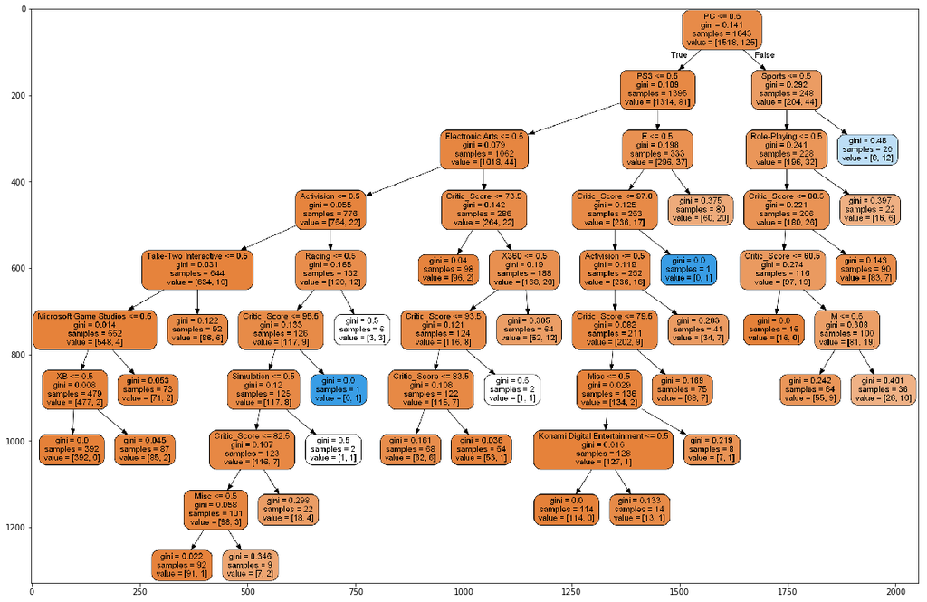

```python
show_tree(dt12, features, 'arbol_normal.png')
```

Árbol Oversampled:

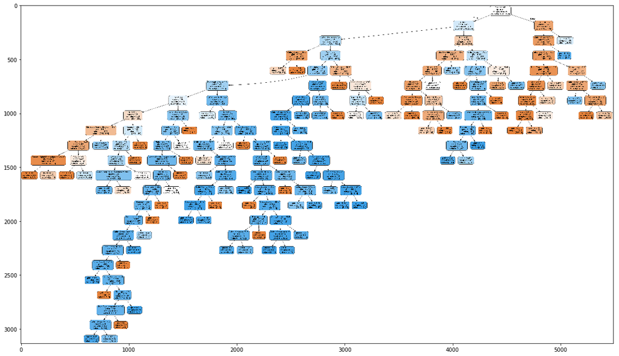

```python
show_tree(dt13, features, 'arbol_oversampled.png')
```

Árbol Subsampled:

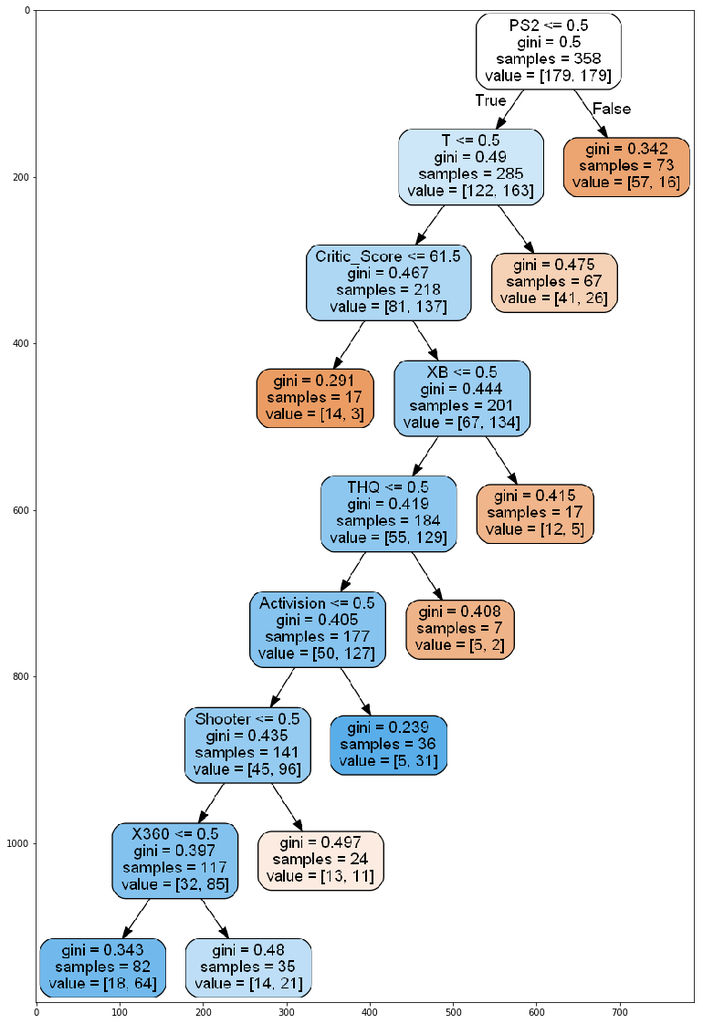

```python
show_tree(dt14, features, 'arbol_subsampled.png')
```

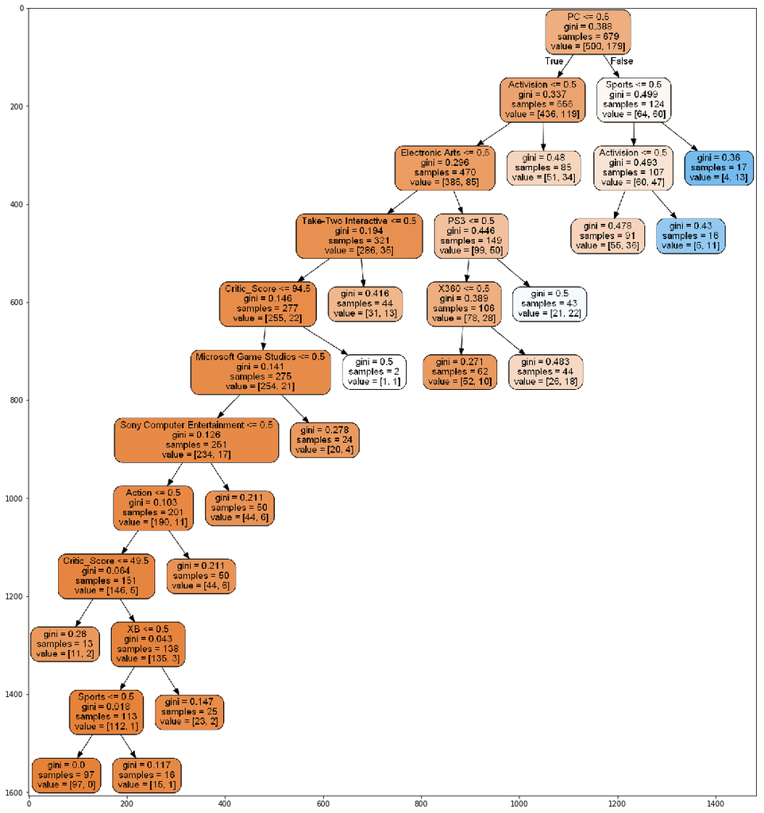

```python
show_tree(dt15, features, 'arbol_master.png')
```

# 6 - Random Forest

Se aplica Random Forest para obtener los atributos que tienen mayor importancia en los árboles de decisión.

```python
clf6 = RandomForestClassifier(n_estimators= 1000,max_depth=100, random_state=0)
train, test= train_test_split(new_data,test_size=.30, stratify=y)


X_train= train[features]
y_train=train["Is_Fiasco"]

X_test=test[features]
y_test=test["Is_Fiasco"]
clf6.fit(X_train, y_train)
import operator
mi_lista_de_tuplas = []
for i in range(33):
    tupla = (header[i],clf6.feature_importances_[i])
    mi_lista_de_tuplas.append(tupla)
mi_lista_de_tuplas.sort(key=operator.itemgetter(1), reverse=True)
for i in range(33):
    print(mi_lista_de_tuplas[i])
```

```
('Critic_Score', 0.48960285203794707)
('PC', 0.039275192530285385)
('Activision', 0.03579991831161546)
('Action', 0.0299711893656454)
('E', 0.02719057600572205)
('Electronic Arts', 0.026953478872364323)
('Sports', 0.02612825988665122)
('PS3', 0.02472333368049525)
('T', 0.024204870927563384)
('Racing', 0.02046394018334239)
('X360', 0.02035819652516221)
('Take-Two Interactive', 0.020183570796898524)
('M', 0.01981540854298209)
('PS2', 0.019293852013349263)
('E10+', 0.019193454323904385)
('XB', 0.017376711104554996)
('Role-Playing', 0.014836590573448492)
('Shooter', 0.01442705819770348)
('Ubisoft', 0.01370313711525391)
('Sega', 0.012748287488666804)
('Simulation', 0.011803259121173838)
('Konami Digital Entertainment', 0.011099581877743016)
('Misc', 0.010796843744189082)
('Sony Computer Entertainment', 0.010516580939576296)
('Microsoft Game Studios', 0.009126664773810703)
('THQ', 0.007199605976866937)
('Platform', 0.006744024597394983)
('Strategy', 0.005705998752362348)
('Adventure', 0.005037737952954403)
('Namco Bandai Games', 0.004075244997370523)
('Fighting', 0.0014629555647844986)
('Puzzle', 0.0001326068605487584)
('AO', 4.901635766861356e-05)
```